# more sample, more likely to be significant?

Main content of this note is to find: **Is the statement ‘more sample, more likely to be significant’ true?**

The example of hypothesis tests in this note are all the case of normal distribution with i.i.d sample $X_1,...,X_n \sim N(\mu,\sigma^2)$.

The analysis can be previewed as:

| test $H_0: \mu \geq \mu_0~~ \text{vs}~~ H_1:\mu<\mu_0$ with significance level $\alpha$ | type I error rate | type II error rate |
| --- | --- | --- |
| $\mu = \mu_0$ | constant $\alpha$ | – |
| $\mu > \mu_0, \mu-\mu_0 = \delta_1$ | upper bounded by $\alpha$, the larger the sample size $n$, the smaller | – |
| $\mu < \mu_0, \mu-\mu_0 = \delta_2$ | – | upper bounded by $1-\alpha$, the larger the sample size $n$, the smaller |

| test $H_0: \mu = \mu_0 ~~ \text{vs}~~ H_1:\mu \neq \mu_0$ with significance level $\alpha$ | type I error rate | type II error rate |
| --- | --- | --- |
| $\mu = \mu_0$ | constant $\alpha$ | – |
| $\mu > \mu_0, \mu-\mu_0 = \delta_1$ | – | upper bounded by $1-\alpha$, the larger the sample size $n$, the smaller |
| $\mu < \mu_0, \mu-\mu_0 = \delta_2$ | – | upper bounded by $1-\alpha$, the larger the sample size $n$, the smaller |

So the ‘more sample, more likely to be significant’ statement makes sense when we are talking about:

- The hypothesis test $H_0: \mu \geq \mu_0~~ \text{vs}~~ H_1:\mu<\mu_0$ with significance level $\alpha$, and we assume the true parameter has some distance with $\mu_0$, then
  - when $H_0$ with $\mu > \mu_0, \mu-\mu_0 = \delta_1$, the larger the sample size $n$, the less likely we make type I error.
  - when $H_1$ with $\mu < \mu_0, \mu-\mu_0 = \delta_2$, the larger the sample size $n$, the less likely we make type II error.
- The hypothesis test $H_0: \mu = \mu_0 ~~ \text{vs}~~ H_1:\mu \neq \mu_0$ with significance level $\alpha$, and we assume the true parameter has some distance with $\mu_0$, then
  - when $H_1$ with $\mu < \mu_0, \mu-\mu_0 = \delta_2$, the larger the sample size $n$, the less likely we make type II error.

# preliminaries

Here are some preliminaries of hypothesis test, skip this part if you already know the basics.

## hypothesis test

$H_0$ null hypothesis and $H_1$ alternative hypothesis.

$$H_0: \theta \in \Theta_0 ~~\text{vs}~
~H_1: \theta \in \Theta_1$$

rejection region: $W$

(Here we only consider non-randomized test)

$$T:
\begin{cases}
X \in W& \text{reject}~H_0\\
X \notin W& \text{accept}~H_0
\end{cases}$$

## two types of error

type I error: $H_0$ but $X \in W$ so we reject $H_0$, probability of type I error: $P_{\theta}\{X \in W\}, \theta \in \Theta_0$, i.e. $P\{X \in W \vert H_0\}$

type II error: $H_1$ but $X \notin W$ so we accept $H_0$, probability of type II error: $P_{\theta}\{X \notin W\}, \theta \in \Theta_1$, i.e. $P\{X \notin W \vert H_1\}$

Note that when we reject $H_0$, then we might make type I error; when we accept $H_0$, we might make type II error.

## power function

$$g(\theta) = P_{\theta}(X \in W),~ \theta
\in \Theta = \Theta_0 \cup \Theta_1$$

$$g(\theta) =
\begin{cases}
\alpha(\theta),& \theta \in \Theta_0\\
1-\beta(\theta),& \theta \in \Theta_1
\end{cases}$$

## significance level

For hypothesis test $H_0: \theta \in \Theta_0 ~~\text{vs}~ ~H_1: \theta \in \Theta_1$, we call the test with significance level $\alpha$ if the test satisfies: for any $\theta \in \Theta_0$,
$$g(\theta) \leq
\alpha$$

# $H_0: \mu \geq \mu_0~~ \text{vs}~~ H_1:\mu<\mu_0$

> Suppose i.i.d sample $X_1,...,X_n \sim N(\mu,\sigma^2)$ with some known $\sigma^2$. For hypothesis test of $H_0: \mu \geq \mu_0$ vs $H_1:\mu<\mu_0$, if the rejection region is $W = \{\frac{\bar{X}-\mu_0}{\sigma/\sqrt{n}} \leq c\}$

From i.i.d sample we know that, $\frac{\bar{X}-\mu}{\sigma/\sqrt{n}}~\sim~N(0,1)$

and the power function is

$$\begin{align}
g(\mu)
& = P_{\mu}(X \in W)\\
& = P(\frac{\bar{X}-\mu_0}{\sigma/\sqrt{n}} \leq c)\\
& = P(\frac{\bar{X}-\mu}{\sigma/\sqrt{n}} +
\frac{\mu-\mu_0}{\sigma/\sqrt{n}} \leq c)\\
& = P(\frac{\bar{X}-\mu}{\sigma/\sqrt{n}} \leq c-
\frac{\mu-\mu_0}{\sigma/\sqrt{n}} )\\
& = \Phi(c- \frac{\mu-\mu_0}{\sigma/\sqrt{n}})
\end{align}$$

It is found that $g(\mu) = g(\mu,c,n)$ is actually a function of

- true parameter $\mu$ (or to say the difference between true parameter and the test bound $\delta = \mu-\mu_0$)
- bound of rejection region $c$
- sample size $n$

## get the rejection region according to significance level

> Calculate the function of probability of type I error $\alpha(\mu,c,n)$

When it comes to talking about type I error rate, the main thing we impose is the range of true parameter $\mu$ to satisfy $H_0$, which means $\mu \geq \mu_0$.

For type I error rate, which is $g(\mu,c,n)$ when $H_0$($\mu \geq \mu_0$), we have

$$\alpha(\mu,c,n) = \Phi(c-
\frac{\mu-\mu_0}{\sigma/\sqrt{n}}) = \Phi(c-
\frac{\mu-\mu_0}{\sigma/\sqrt{n}}),~ \mu \geq \mu_0$$

When it comes further to talking about significance level, the main thing we care about is to control the maximize of type I error rate, which means

$$max(\alpha(\mu,c,n)) \leq
\alpha$$
Note here that $\alpha(\mu,c,n)$ is a decreasing function of $\mu$, so it get maximum value at $\mu=\mu_0$, which means
$$max(\alpha(\mu,c,n))= \alpha(\mu_0,c,n) = \Phi(c
- \frac{\mu_0-\mu_0}{\sigma/\sqrt{n}})= \Phi(c)$$
which is function of $c$(by this step the sample size $n$ disappear!)

Let $\Phi(c) = \alpha$ and we get $c=u_{\alpha}$

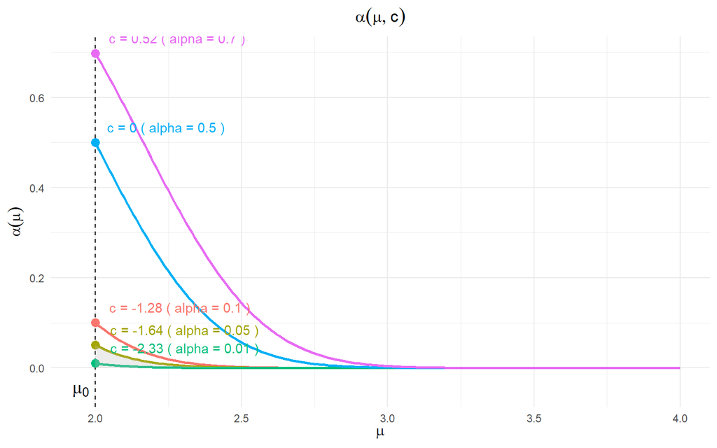

So we can rewrite the hypothesis test with a significance level of $\alpha$ as:

$$X_1,...,X_n \sim
N(\mu,\sigma^2)$$

$$H_0: \mu \geq \mu_0~~ \text{vs}~~
H_1:\mu<\mu_0$$
$$T:
\begin{cases}
\frac{\bar{X}-\mu_0}{\sigma/\sqrt{n}} \leq u_{\alpha}, &
\text{reject}~H_0\\
\frac{\bar{X}-\mu_0}{\sigma/\sqrt{n}} > u_{\alpha}, &
\text{accept}~H_0
\end{cases}$$

## type I error rate

The question does not stop here(Note that the significance level only restricts the bound of type I error rate).

After we set the significance level $\alpha$ and get the corresponding test(with rejection region as $W = \{\frac{\bar{X}-\mu_0}{\sigma/\sqrt{n}} \leq c\}, c = u_{\alpha}$), we can calculate the probability of making type I error under different true parameter $\mu$ that satisfies $H_0$:

$$\alpha(\mu,n) = \Phi(u_{\alpha}-
\frac{\mu-\mu_0}{\sigma/\sqrt{n}}),~\mu \geq \mu_0$$

> How does the type I error rate change with sample size?

Set $\sigma = 1, \mu_0 = 2$ and significance level $\alpha=0.05$, the type I error rate is the function of true parameter $\mu$ and sample size $n$

$$\alpha(\mu,n) = \Phi(u_{0.05} -
\frac{\mu-2}{1/\sqrt{n}}),~\mu \geq 2$$

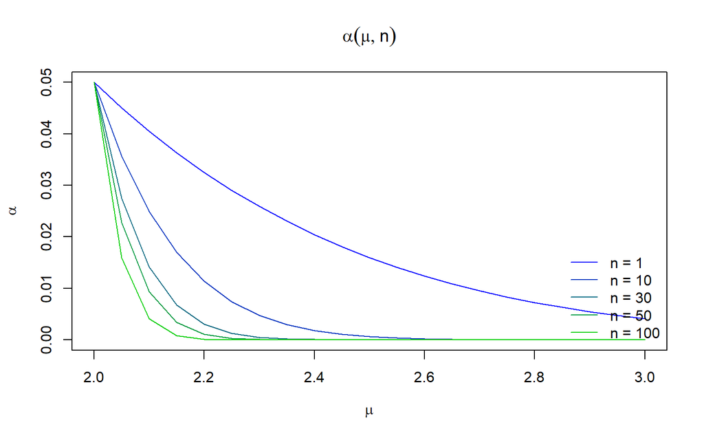

We can see from the plot above that:

- The type I error rate is always smaller than the significance level $\alpha=0.05$.
- When the true parameter equals the test bound(?another name) $\mu = \mu_0$, the type I error rate stays 0.05, and does not change with sample size.
- When the true parameter is different from the test bound:
  - the larger the sample size $n$, the less likely we make type I error.
  - the larger the difference $\delta = \mu-\mu_0$, the less likely we make type I error.

We can also make simulations(sample m = 10000 times under different $\mu$ and different sample size $n$, calculate the ratio of making type I error rate), and the result is consistent with the statistical analysis.

```
## [1] "Proportion of rejecting H0(repeat m = 10000 times):"
```

|  | n=1 | n=10 | n=30 | n=50 | n=100 |
| --- | --- | --- | --- | --- | --- |
| μ = 2 | 0.050 | 0.051 | 0.053 | 0.047 | 0.051 |
| μ = 2.1 | 0.040 | 0.027 | 0.014 | 0.008 | 0.004 |
| μ = 2.5 | 0.018 | 0.000 | 0.000 | 0.000 | 0.000 |
| μ = 3 | 0.004 | 0.000 | 0.000 | 0.000 | 0.000 |

## type II error rate

> Calculate the function of probability of type II error $\beta(\mu,c,n)$

When it comes to talking about type II error rate, the main thing we impose is the range of true parameter $\mu$ to satisfy $H_1$, which means $\mu < \mu_0$.

For type II error rate, which is $1-g(\mu,c,n)$ when $H_1$($\mu < \mu_0$), we have

$$\beta(\mu,c,n) = 1-\Phi(c-
\frac{\mu-\mu_0}{\sigma/\sqrt{n}}),~\mu < \mu_0$$

After we set $c = u_{\alpha}$, we can calculate the probability of making type II error under different true parameter $\mu$ that satisfies $H_1$

$$\beta(\mu,n) = 1-\Phi(u_{\alpha} -
\frac{\mu-\mu_0}{\sigma/\sqrt{n}}),~\mu < \mu_0$$

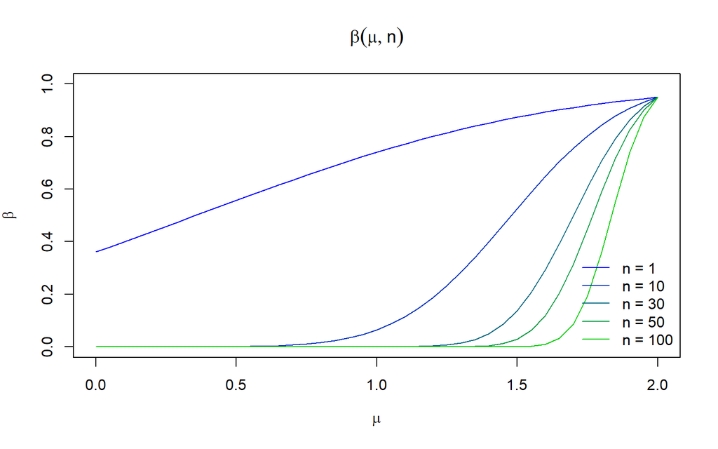

We can see from the plot above that:

- The type II error rate is always smaller than 1 - the significance level $\beta <0.95$, the upper bound is at $\mu = \mu_0$
- When the true parameter is different from the test bound(always the case when considering type II error):
  - the larger the sample size $n$, the less likely we make type II error.
  - the larger the difference $\delta = \mu-\mu_0$, the less likely we make type II error.

| – | type I error rate | type II error rate |
| --- | --- | --- |
| $\mu = \mu_0$ | constant $\alpha$ | – |
| $\mu > \mu_0, \mu-\mu_0 = \delta_1$ | upper bounded by $\alpha$, the larger the sample size $n$, the smaller | – |
| $\mu < \mu_0, \mu-\mu_0 = \delta_2$ | – | upper bounded by $1-\alpha$, the larger the sample size $n$, the smaller |

# $H_0: \mu = \mu_0~~ \text{vs}~~ H_1:\mu<\mu_0$

This test is slightly different from the one above, with $H_0: \mu = \mu_0$ and $H_1:\mu<\mu_0$, which means that the whole range of $\mu$ is $(-\infty, \mu_0]$ and the case of $\mu>\mu_0$ is never considered.

So in this case, the type I error rate stays

$$\alpha(\mu,n) = \Phi(u_{0.05}-
\frac{\mu-\mu_0}{\sigma/\sqrt{n}}) = 0.05,~\mu=\mu_0$$

| – | type I error rate | type II error rate |
| --- | --- | --- |
| $\mu = \mu_0$ | constant $\alpha$ | – |
| $\mu < \mu_0, \mu-\mu_0 = \delta_1$ | – | upper bounded by $1-\alpha$, the larger the sample size $n$, the smaller |

# $H_0: \mu = \mu_0 ~~ \text{vs}~~ H_1:\mu \neq \mu_0$

Here we considered the two-sided test

> Suppose i.i.d sample $X_1,...,X_n \sim N(\mu,\sigma^2)$ with some known $\sigma^2$. For hypothesis test of $H_0: \mu = \mu_0$ vs $H_1:\mu \neq \mu_0$, if the rejection region is $W = \{|\frac{\bar{X}-\mu_0}{\sigma/\sqrt{n}}| \geq c\}$, calculate the function of probability of type I error $\alpha(\mu)$, and calculate the parameter of rejection region $c$ that satisfying $\alpha(\mu) \leq 0.05, \forall \mu = \mu_0$

From i.i.d sample we know that, $\frac{\bar{X}-\mu}{\sigma/\sqrt{n}}~\sim~N(0,1)$

and the power function is

$$\begin{align}
g(\mu)
& = P_{\mu}(X \in W)\\
& = P(|\frac{\bar{X}-\mu_0}{\sigma/\sqrt{n}}| \geq c)\\
& = P(|\frac{\bar{X}-\mu}{\sigma/\sqrt{n}} +
\frac{\mu-\mu_0}{\sigma/\sqrt{n}}| \geq c)\\
& = P(\frac{\bar{X}-\mu}{\sigma/\sqrt{n}} +
\frac{\mu-\mu_0}{\sigma/\sqrt{n}} \geq |c|)
+ P(\frac{\bar{X}-\mu}{\sigma/\sqrt{n}} +
\frac{\mu-\mu_0}{\sigma/\sqrt{n}} \leq -|c|) \\
& = P(\frac{\bar{X}-\mu}{\sigma/\sqrt{n}} \geq |c| -
\frac{\mu-\mu_0}{\sigma/\sqrt{n}}) +
P(\frac{\bar{X}-\mu}{\sigma/\sqrt{n}} \leq -|c| -
\frac{\mu-\mu_0}{\sigma/\sqrt{n}})\\
& = 1-\Phi(|c| - \frac{\mu-\mu_0}{\sigma/\sqrt{n}}) + \Phi(-|c| -
\frac{\mu-\mu_0}{\sigma/\sqrt{n}})
\end{align}$$

It is found that $g(\mu) = g(\mu,c,n)$ is actually a function of

- true parameter $\mu$ (or to say the difference between true parameter and the test bound $\delta = \mu-\mu_0$)
- bound of rejection region $c$
- sample size $n$

## get the rejection region according to significance level

> Calculate the function of probability of type I error $\alpha(\mu,c,n)$

Here the type I error rate is:

$$\begin{align}
\alpha(\mu,c,n)
&= 1-\Phi(|c| - \frac{\mu-\mu_0}{\sigma/\sqrt{n}}) + \Phi(-|c| -
\frac{\mu-\mu_0}{\sigma/\sqrt{n}}),~ \mu=\mu_0 \\
&= 1-\Phi(|c| - \frac{\mu_0-\mu_0}{\sigma/\sqrt{n}}) + \Phi(-|c| -
\frac{\mu_0-\mu_0}{\sigma/\sqrt{n}}) \\
& = 2(1-\Phi(|c|))
\end{align}$$

which is itself a function of only $c$.

> Calculate the rejection region bound $c$ that satisfying $\alpha(\mu,c,n) \leq 0.05, \forall \mu = \mu_0$

When it comes further to talking about significance level, the main thing we care about is to control the maximize of type I error rate, which means

So we can rewrite the hypothesis test with a significance level of $\alpha$ as:

## type I error rate

> How does the type I error rate change with sample size?

From the analysis above we find that discussing sample size in the sense of type I error is meaningless as neither $\alpha(\mu,c)$ nor $max(\alpha(\mu,c))$ change according to $n$.

## type II error rate

> Calculate the function of probability of type II error $\beta(\mu,c,n)$

When it comes to talking about type II error rate, the main thing we impose is the range of true parameter $\mu$ to satisfy $H_1$, which means $\mu \neq \mu_0$.

For type II error rate, which is $1-g(\mu,c,n)$ when $H_1$($\mu \neq \mu_0$), we have

$$\beta(\mu,c,n) = \Phi(|c| -
\frac{\mu-\mu_0}{\sigma/\sqrt{n}}) - \Phi(-|c| -
\frac{\mu-\mu_0}{\sigma/\sqrt{n}}) ,~ \mu \neq \mu_0$$

After we set $c = u_{\alpha/2}$, we can calculate the probability of making type II error under different true parameter $\mu$ that satisfies $H_1$

$$\beta(\mu,n) = \Phi(|u_{\alpha/2}| -
\frac{\mu-\mu_0}{\sigma/\sqrt{n}}) - \Phi(-|u_{\alpha/2}| -
\frac{\mu-\mu_0}{\sigma/\sqrt{n}}),~ \mu \neq \mu_0$$

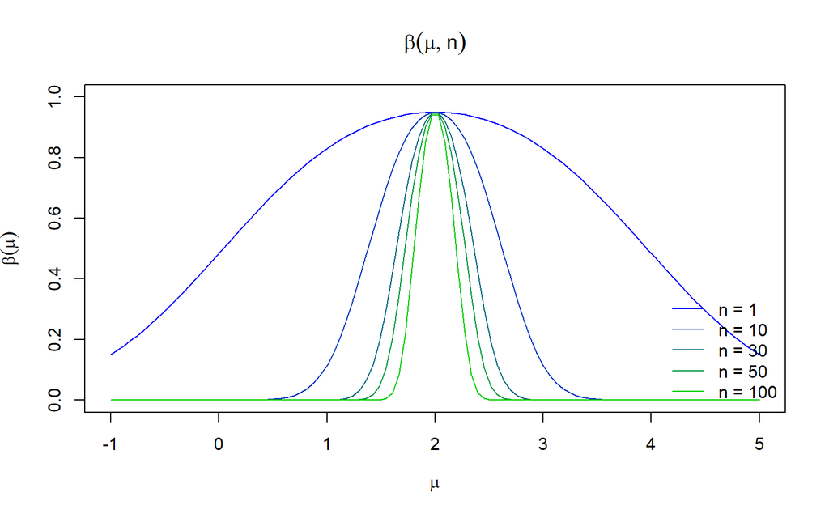

We can see from the plot above that:

- The type II error rate is always smaller than 1 - the significance level $\beta=0.95$, the upper bound is at $\mu = \mu_0$
- When the true parameter is different from the test bound(always the case when considering type II error):
  - the larger the sample size $n$, the less likely we make type II error.
  - the larger the difference $\delta = \mu-\mu_0$, the less likely we make type II error.

| – | type I error rate | type II error rate |
| --- | --- | --- |
| $\mu = \mu_0$ | constant $\alpha$ | – |
| $\mu > \mu_0, \mu-\mu_0 = \delta_1$ | – | upper bounded by $1-\alpha$, the larger the sample size $n$, the smaller |
| $\mu < \mu_0, \mu-\mu_0 = \delta_2$ | – | upper bounded by $1-\alpha$, the larger the sample size $n$, the smaller |

# appendix

The curve of standard normal distribution $\Phi(x)$:

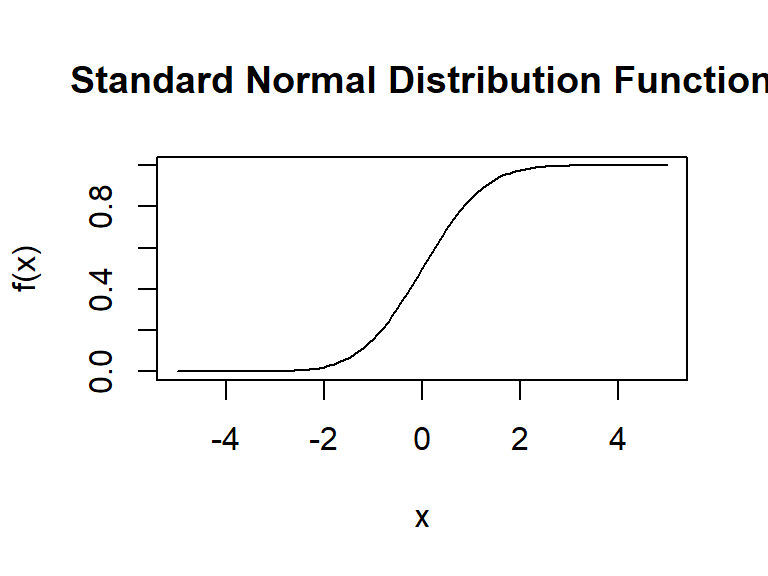

If we know $\sigma^2 = 1$, and set $n = 10$, $c = 1.645$ and $\mu_0 = 2$, the power function is a decreasing function of $\mu$:

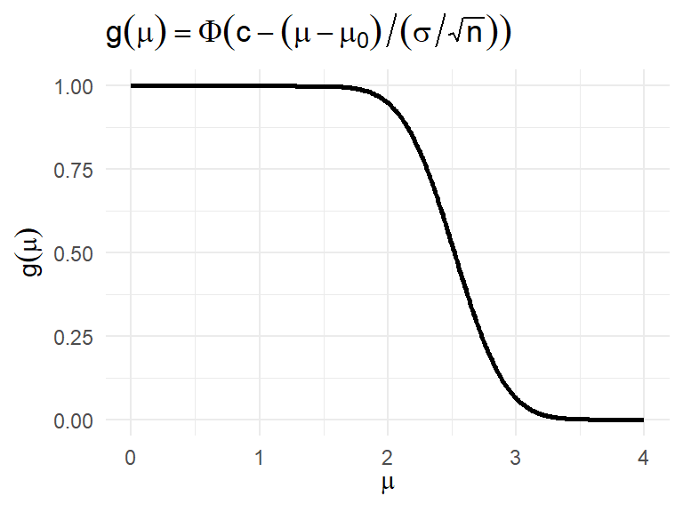

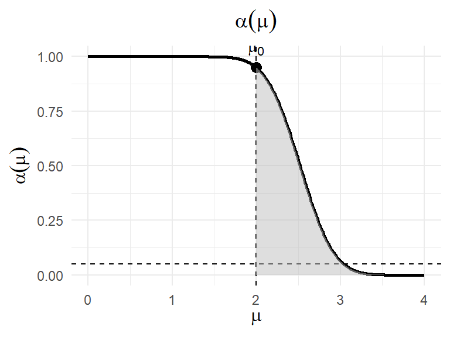

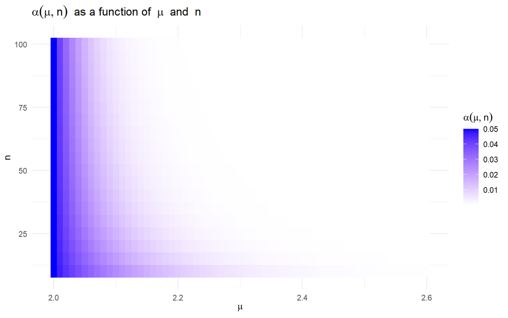

Codes of this note

```r
# Parameter settings
n <- 10
sigma2 <- 1
sigma <- sqrt(sigma2)
mu0 <- 2
alpha <- 0.05 # Significance level

# Power function g(mu)
g <- function(mu, c) {
  pnorm(c - (mu - mu0) / (sigma / sqrt(n)))
}

# Define multiple critical values
# c_values <- c(-1.645, 1.28, 1.645, 2.33) # Example critical values (corresponding to different alpha levels)
alpha_values <- c(0.01, 0.05, 0.1, 0.5, 0.7) # Associated alpha levels
c_values <- round(qnorm(alpha_values),2)

# Create plotting data for all c values
mu_values <- seq(2, 4, by = 0.01)
all_data <- do.call(rbind, lapply(seq_along(c_values), function(i) {
  data.frame(
    mu = mu_values,
    g_mu = g(mu_values, c_values[i]),
    c_value = paste("c =", c_values[i], "(", expression(alpha), "=", alpha_values[i], ")")
  )
}))

# Key points for marking
key_points <- data.frame(
  c_value = paste("c =", c_values, "(", expression(alpha), "=", alpha_values, ")"),
  mu = mu0,
  g_mu = sapply(c_values, function(c) g(mu0, c))
)

# Highlight region for the default critical value
highlight_data <- data.frame(
  mu = mu_values[mu_values >= mu0],
  g_mu = g(mu_values[mu_values >= mu0], c_values[2]), # Default to c = 1.645 (alpha = 0.05)
  c_value = paste("c =", c_values[2],  "(", expression(alpha), "=", alpha_values[2], ")")
)

# Plotting
ggplot(all_data, aes(x = mu, y = g_mu, color = c_value)) +
  geom_line(linewidth = 1) + # Curves for each c
  geom_vline(xintercept = mu0, linetype = "dashed", color = "black") + # Vertical line for mu0
  geom_point(data = key_points, aes(x = mu, y = g_mu), size = 3) + # Key points for mu0
  geom_text(data = key_points, aes(x = mu, y = g_mu, label = c_value),
            vjust = -1, hjust = -0.1, parse = FALSE) + # Label for each curve
  geom_ribbon(data = highlight_data, aes(x = mu, ymin = 0, ymax = g_mu),
              fill = "gray", alpha = 0.3, inherit.aes = FALSE) + # Highlight region
  labs(
    x = expression(mu),
    y = expression(alpha(mu)),
    title = expression(alpha(mu,c)),
    color = "Critical Value"
  ) +
  annotate("text", x = mu0-0.05, y = -0.05, label = 'mu[0]', parse=TRUE, size = 5, hjust = 0.5) + # Label below x-axis
  theme_minimal() +
  theme(
    plot.title = element_text(hjust = 0.5),
    axis.title.x = element_text(size = 12),
    axis.title.y = element_text(size = 12),
    legend.position = "none"
  )
```

```r
# Define the function
Phi <- function(mu, mu0, sigma, n, u_0.05) {
  # Calculate the standardized variable
  z <- u_0.05 - (mu - mu0) / (sigma / sqrt(n))
  # Return the cumulative distribution value of the standard normal distribution
  return(pnorm(z))
}

# Parameter settings
mu0 <- 2
sigma <- 1
u_0.05 <- qnorm(0.05)

# Range of the variable mu
mu_values <- seq(2, 3, by = 0.05)

# Different sample sizes to compare
n_values <- c(1, 10, 30, 50, 100)

# Compute Phi values for each n
Phi_results <- lapply(n_values, function(n) {
  sapply(mu_values, function(mu) Phi(mu, mu0, sigma, n, u_0.05))
})

# Create a gradient color palette
colors <- colorRampPalette(c("blue", "green3"))(length(n_values))

# Plot the results
plot(mu_values, Phi_results[[1]], type = "l", col = colors[1],
     xlab = expression(mu), ylab = expression(alpha),
     main = expression(alpha(mu,n)),
     ylim = c(0, 0.05)) # Set consistent y-axis limits

# Add lines for other sample sizes using the gradient colors
for (i in 2:length(n_values)) {
  lines(mu_values, Phi_results[[i]], col = colors[i])
}

# Add a legend
legend("bottomright", legend = paste("n =", n_values),
       col = colors, lty = 1, bty = "n")
```

```r
# Parameter settings
mu_values <- c(2,2.1,2.5,3)  # Different true mean values
mu_0 <- 2                         # Hypothesized mean (under H0)
sigma <- 1                        # Standard deviation
alpha <- 0.05                     # Significance level
n_values <- c(1, 10, 30, 50, 100)    # Different sample sizes
num_trials <- 10000               # Number of trials

# Critical value
u_alpha <- qnorm(alpha)

# Initialize a matrix to store results
results <- matrix(0, nrow = length(mu_values), ncol = length(n_values))
colnames(results) <- paste0("n=", n_values)
rownames(results) <- paste0("μ = ", mu_values)  # Use Greek letter mu

# Simulation process
for (i in seq_along(mu_values)) {
  mu <- mu_values[i]
  for (j in seq_along(n_values)) {
    n <- n_values[j]
    reject_count <- 0

    for (k in 1:num_trials) {
      # Generate samples
      samples <- rnorm(n, mean = mu, sd = sigma)
      x_bar <- mean(samples)
      # Compute test statistic
      T <- (x_bar - mu_0) / (sigma / sqrt(n))
      # Check if H0 is rejected
      if (T <= u_alpha) {
        reject_count <- reject_count + 1
      }
    }

    # Record the proportion of rejecting H0
    results[i, j] <- reject_count / num_trials
  }
}

# Display the results as a table
print("Proportion of rejecting H0(repeat m = 10000 times):")
kable(round(results, 3))
```

```r
# Define the function
Phi <- function(mu, mu0, sigma, n, u_0.05) {
  # Calculate the standardized variable
  z <- u_0.05 - (mu - mu0) / (sigma / sqrt(n))
  # Return the cumulative distribution value of the standard normal distribution
  return(1-pnorm(z))
}

# Parameter settings
mu0 <- 2
sigma <- 1
u_0.05 <- qnorm(0.05)

# Range of the variable mu
mu_values <- seq(0, 2, by = 0.05)

# Different sample sizes to compare
n_values <- c(1, 10, 30, 50, 100)

# Compute Phi values for each n
Phi_results <- lapply(n_values, function(n) {
  sapply(mu_values, function(mu) Phi(mu, mu0, sigma, n, u_0.05))
})

# Create a gradient color palette
colors <- colorRampPalette(c("blue", "green3"))(length(n_values))

# Plot the results
plot(mu_values, Phi_results[[1]], type = "l", col = colors[1],
     xlab = expression(mu), ylab = expression(beta),
     main = expression(beta(mu,n)),
     ylim = c(0, 1)) # Set consistent y-axis limits

# Add lines for other sample sizes using the gradient colors
for (i in 2:length(n_values)) {
  lines(mu_values, Phi_results[[i]], col = colors[i])
}

# Add a legend
legend("bottomright", legend = paste("n =", n_values),
       col = colors, lty = 1, bty = "n")
```